# STA106 Project 2 - Two Factor ANOVA - Scores.csv

Chris Cheng 5/29/2019

## Introduction

```r
the.data = Scores
the.data <- as.data.frame(the.data)
names(the.data) = c("Y","A","B")

the.model = lm(Y ~ A*B, data = the.data)
the.model$coefficients
```

```
##      (Intercept)        APrevious          ARecent           BShort
##      15.83870968       0.06129032       5.16129032       3.41991101
## APrevious:BShort   ARecent:BShort
##       2.01342232      -0.24848244
```

This Two-Factor ANOVA dataset is characterized by the Full Interaction effect regression formation model:
$$Y_i=\beta_0+\beta_1X_{A,Previous}+\beta_2X_{A,Recent}+
\beta_3X_{B,Short}+\beta_4X_{A,Previous}X_{B,Short}+
\beta_5X_{A,Recent}X_{B,Short}+\varepsilon_i$$

The estimated coefficients are as follows:
$$\hat{\beta_0}=15.8387$$
$$\hat{\beta_1}=0.0613$$
$$\hat{\beta_2}=5.1613$$
$$\hat{\beta_3}=3.4199$$
$$\hat{\beta_4}=2.0134$$
$$\hat{\beta_5}=-0.2485$$

## Data Summary

**Five Number Summary of Beck Scores**

| Minimum | 25th Percentile | Median | 75th Percentile | Maximum |
| --- | --- | --- | --- | --- |
| 1 | 13 | 20 | 28 | 50 |

The five-number summary of BECK depression scores is shown in the table above. Subjects are assigned a score between 0 to 75, inclusive. In this sample taken from a “high risk population”, the minimum score is 1, the first quartile score is 13, the median score sampled is 20, the third quartile score is 28, and the maximum score sampled is 50.

**Mean BECK Scores by Factor Levels**

|  | Drug History | BECK Score |
| --- | --- | --- |
| 1 | Never | 18.07 |
| 2 | Previous | 19.39 |
| 3 | Recent | 23.67 |

When only the subjects’ history of drug use is taken into account, it appears that subjects who have recently used recreational drugs (Recent) on average score the highest, whereas those who have previously but not recently used recreational drugs on average score the second highest, and those who have never used recreational drugs on average score the lowest. The data therefore suggests that subjects who have recently used recreational drugs are the most at risk for depression, while the subjects who have never used recreational drugs are the least at risk for depression.

|  | Treatment Length | BECK Score |
| --- | --- | --- |
| 1 | Long | 17.09 |
| 2 | Short | 21.87 |

When only the subjects’ psychological treatment length is taken into account, it appears that subjects who receive less than a year of treatment (Short) on average score higher on the depression index than those who have been receiving treatment for a year or more (Long), and so are therefore at more risk for depression.

**Interaction Plots by Treatment Group and Mean BECK Scores by Treatment Group**

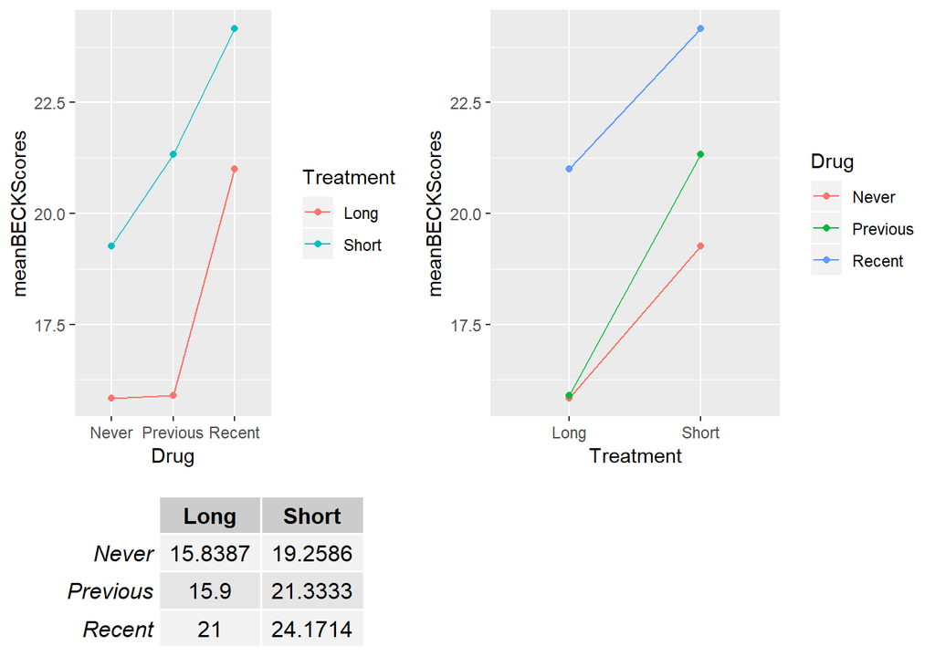

Plotting the interaction plot between the subjects’ history of drug use (Factor A) and the length of time that they have been receiving psychological treatment (Factor B), it appears that interaction effects may be present. The average BECK depression score that a subject in the factor level denoted by the x-axis receives clearly depends on which of the second factor level (denoted by the color of the line) the subject is part of. For example, the first plot clearly shows that the two lines are not parallel, thereby suggesting that the average BECK score received by a subject in a Drug History factor level depends on which Treatment length factor level (Long or Short) the subject is in.  
**Boxplot by Treatment Group and Standard Deviations of BECK Scores by Treatment Group**

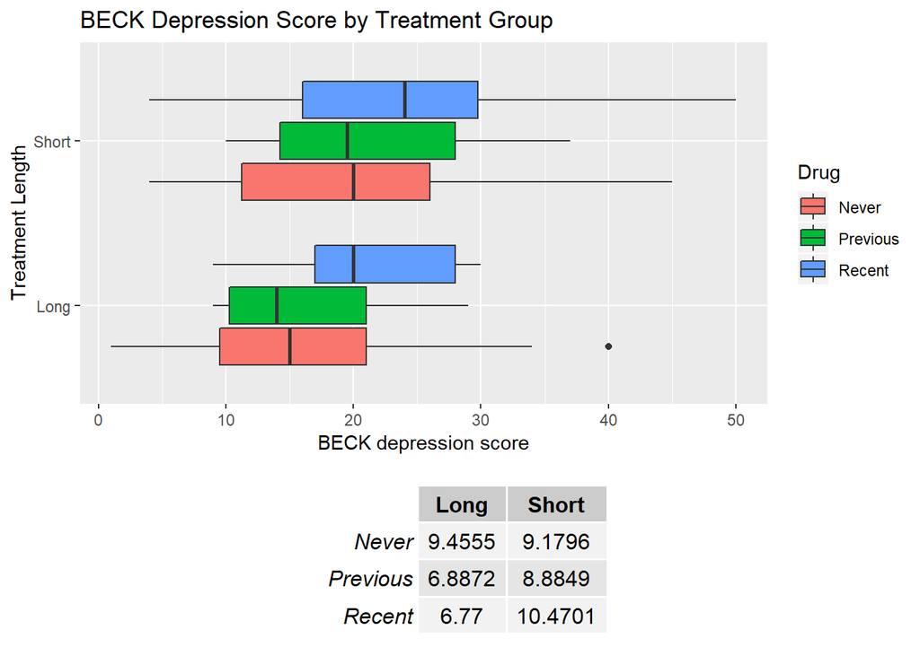

From a superficial glance it appears that the standard deviations of the depression scores by treatment group do not differ much from each other, suggesting that the equal variance by treatment group assumption is not violated and that a Two-Factor ANOVA model may possibly be used to fit this data. This is because we argue that all six boxplots of treatment groups appear to cover a reasonably similar horizontal spread of BECK scores and that the two-way table standard deviation values are roughly similar values.

However, we will need to conduct a formal diagnostic Brown-Forsythe test for equal group variances in order to rigorously test this assumption.

**Boxplots by Factor Levels**

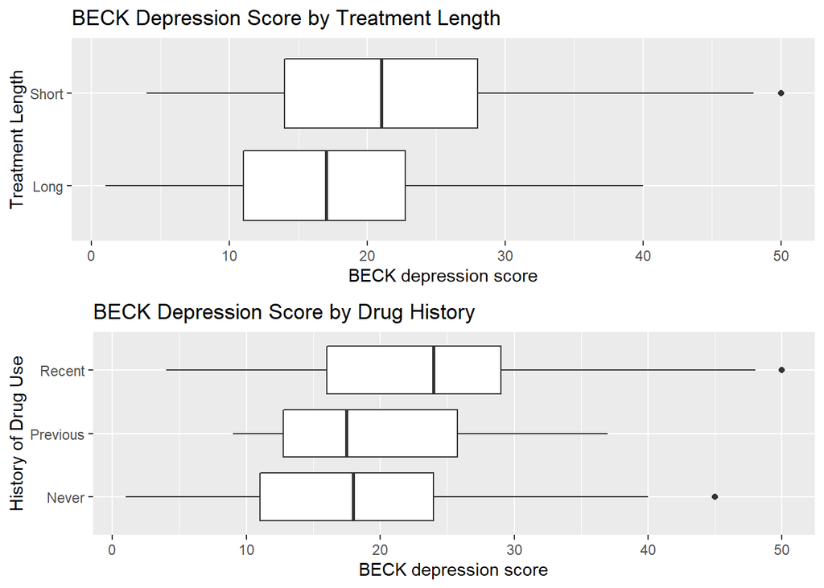

**Barplot by Treatment Groups**

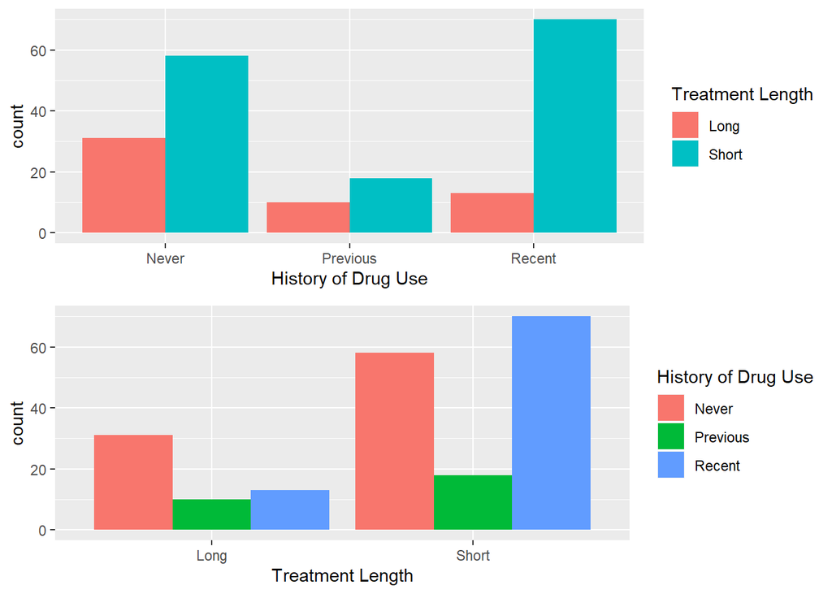

**Histogram by Factors**

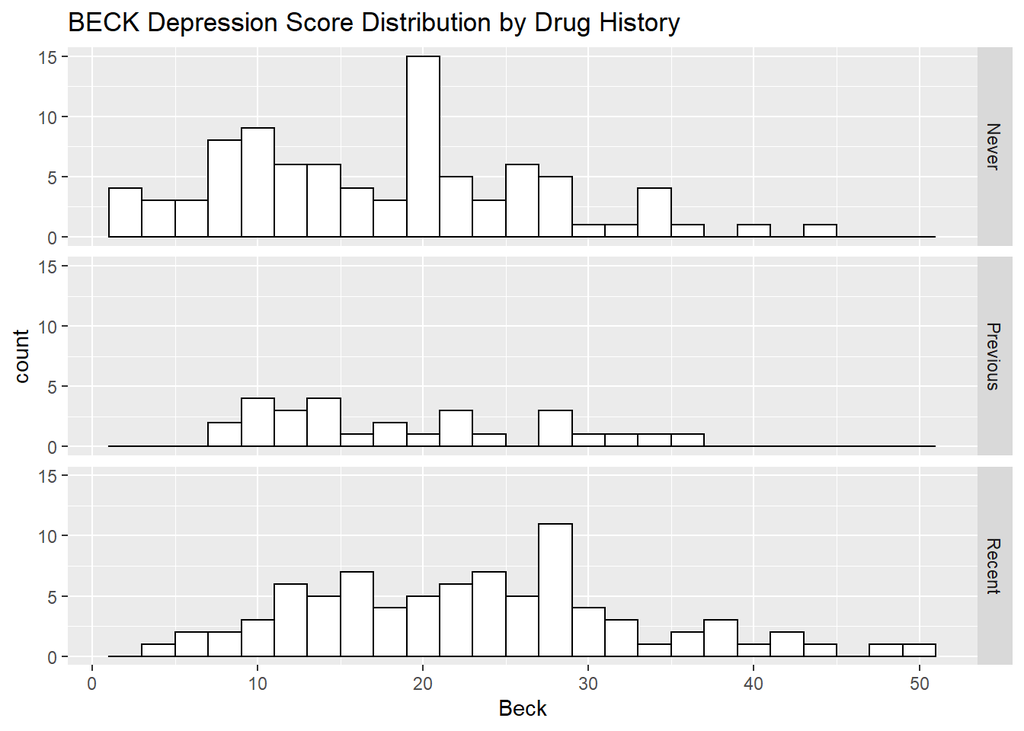

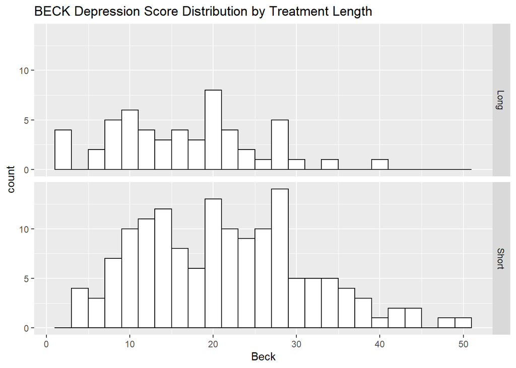

## Diagnostics

**Conduct Diagnostic Tests using A*B interaction effects model**

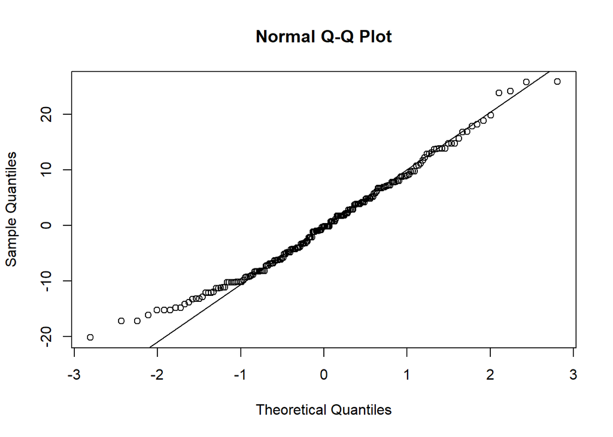

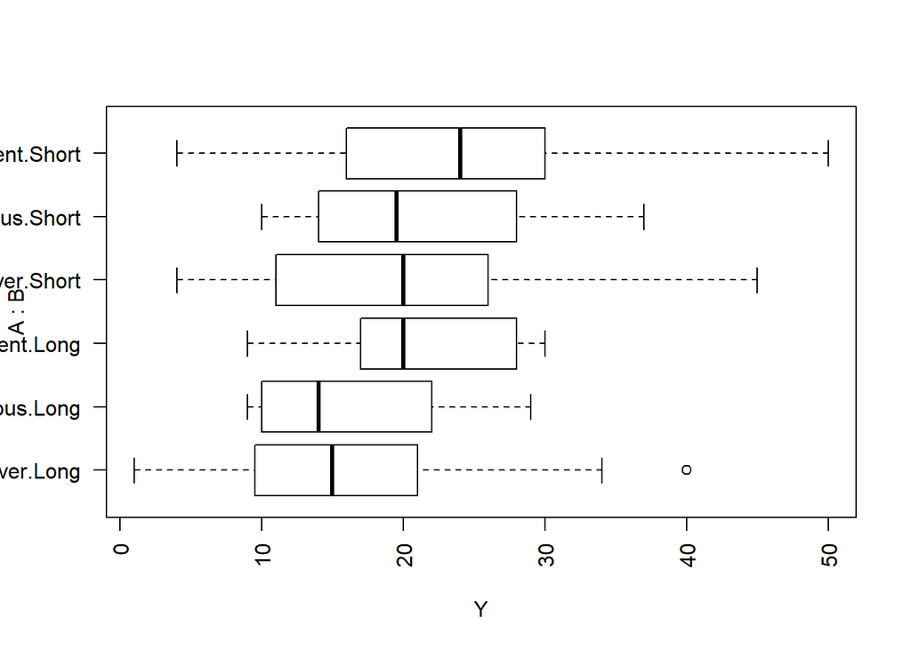

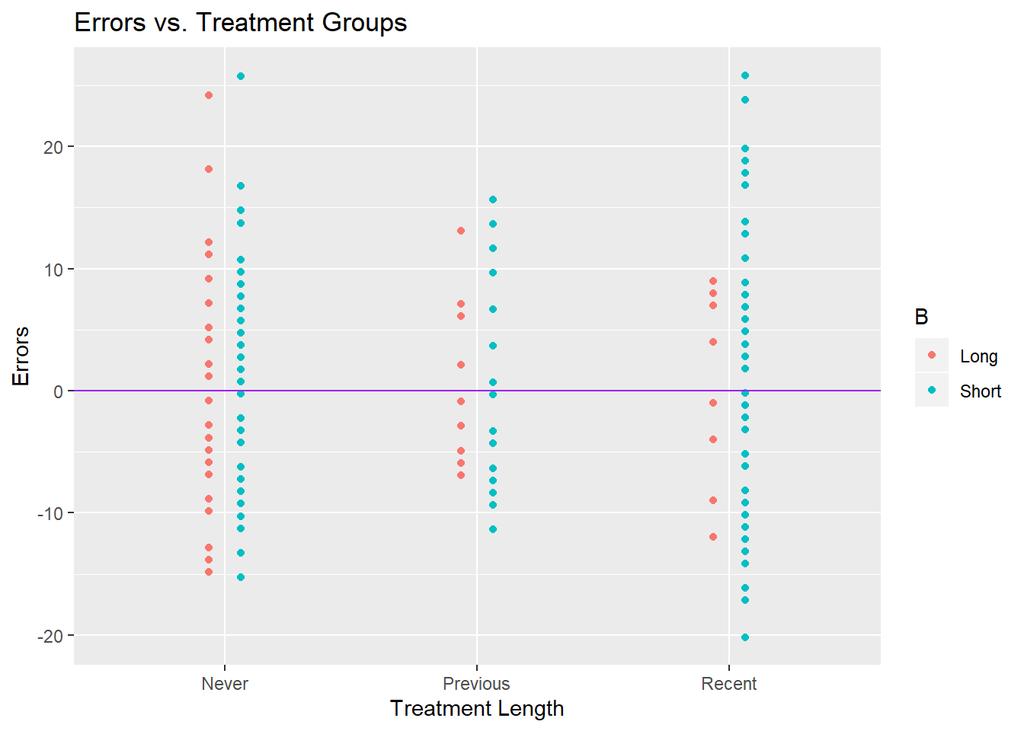

| _ | Shapiro-Wilk Test | Brown-Forsythe Test |
| --- | --- | --- |
| p-value | 0.0273 | 0.4267 |

We use the A*B interaction effects model for diagnostics and first plot a QQplot of the residuals (ei) in order to superficially assess the normality of the errors assumption. The QQplot suggests that the data appear to be distributed approximately normal as most points lie near or on the projected line that indicates the plot of a completely normal dataset. There is a collection of points at the left tail that deviate slightly above the projected line, indicating that multiple low value sample BECK scores are slightly larger than what they would be under a completely normal distribution. The plot suggests that the most negative residual (left-most) point may be an outlier but we need to more rigorously use semi-studentized and studentized residual cutoffs to make a stronger case.

From the boxplot by treatment groups, it appears that the variances in BECK score of all treatment groups appear to be approximately equal because all box bodies appear to overlap well with each other with almost 50% pairwise overlap in all bodies. However, the errors vs. treatment groups plot suggests that the variance in BECK scores between the recent drug usage and long treatment length and recent drug usage short treatment length subjects is quite different, so we need to conduct the Brown-Forsythe test in order to make a strong conclusion about the treatment group variances.

We conduct both a Shapiro-Wilks test and Brown-Forsythe test in order to more rigorously assess the normality of errors and equal treatment group variances assumptions, respectively. Before conducting these two tests, we choose to use an alpha of 0.05 so as to avoid any post-hoc hypothesis test interpretations.

The null hypothesis of the SW test is that all of the errors are distributed normal with a mean of zero and standard deviation of (sigma)^2_epsilon, while the alternate hypothesis is that the errors are not distributed normal. At an alpha of 0.05, the Shapiro-Wilks test p-value of 0.0273 is less than alpha and so we reject the null hypothesis and conclude that the errors are not normally distributed. This result suggests that the normality of errors assumption has been violated.

The null hypothesis of the BF test is that all population treatment group variances are equal to each other (sigma_11)^2 = (sigma_12)^2=…, while the alternate hypothesis is that at least one population treatment group variance is not equal to that of the other treatment groups. At an alpha of 0.05, the Brown-Forsyte test p-value of 0.4267 is greater than alpha and so we fail to reject the null hypothesis and conclude that the equal treatment group variances assumption has not been violated.

We do not conduct a transformation of variables in order to satisfy the normality of errors assumption here.

## Analysis of Results

**Test for Best Model**

| F test of Full Model to Reduced Model | F test statistic | p-value | Conclusion at p=0.05 | Conditional R2 value |
| --- | --- | --- | --- | --- |
| AB vs. A.B | 0.1338 | 0.8748 | Fail to reject Null | 0.0014 |
| A.B vs. B | 5.7742 | 0.0172 | Reject Null | 0.0286 |
| A.B vs. A | 5.6852 | 0.0040 | Reject Null | 0.0548 |

We determine the best model as follows, with Factor A denoting the subjects’ history of recreational drug use and Factor B denoting the length of time over which the subjects have been receiving psychological treatment:

We first determine whether or not to include the interaction effect term in our model with;
$$H_0: (\gamma\delta)_{ij}=0\ for\ all\ i,j$$
$$H_A:
at\ least\ one\ (\gamma\delta)_{ij}\neq0\ for\ an\ i,j$$
At an alpha of 0.05, the p-value (0.8748) is greater than alpha so we fail to reject the null hypothesis and conclude that all interaction effect terms are equal to zero for all factor levels of the subjects’ history of drug use and the length of time that they have been receiving treatment. We thus conclude that the model that includes information on the the subjects’ history of drug use and length of time over which they have been receiving treatment is a statistically better fit than the model that includes information on both said factor effects and the interaction effect between the subjects’ history of drug use and treatment duration.

We then determine whether or not to include the effect of the subjects’ history of drug use to a model with the effect of the subject’s treatment length:
$$H_0: \gamma_{i}=0\ for\ all\ i$$
$$H_A: at\ least\ one\ \gamma_{i}\neq0\ for\ an\ i$$

At an alpha of 0.05, the p-value(0.0172) is less than alpha so we reject the null hypothesis and conclude that at least one effect of the subjects’ history of drug use is not equal to that of the others. Therefore, the model that includes information on both the subjects’ history of drug use and the length of time over which the subject has been receiving treatment is a statistically better fit than the model that only includes information on the length of time over which the subject has been receiving treatment.

We conclude by determining whether or not to include the effect of the length of time over which the subject has been receiving psychological treatment to a model with the effect of the subjects’ drug use history:
$$H_0: \delta_{j}=0\ for\ all\ j$$
$$H_A: at\ least\
one\ \delta_{j}\neq0\ for\ a\ j$$

At an alpha of 0.05, the p-value(0.0040) is less than alpha so we reject the null hypothesis and conclude that at least one effect of the subject’s treatment length is not equal to that of the others. Therefore, the model that includes information both on the subject’s treatment length and drug use history is a statistically better fit than the model that only includes information on the subject’s drug use history.
We conclude that the best model to use is the model that does not contain the interaction effects term and only contains both factor effects terms:
$$Y_{ijk}=\mu_{..}+\gamma_{i}+\delta_{j}+\varepsilon_{ijk}$$

We calculated the following three conditional R^2 values:  
1) When we add information about the interaction between the subjects’ recreational drug use history and length of psychological treatment to a model with information on both the subjects’ recreational drug use history and length of psychological treatment, there is an overall 0.14% reduction in error.  
2) When we add information about the subjects’ recreational drug use history to a model with information on the subjects’ length of psychological treatment, there is an overall 2.86% reduction in error.  
3) When we add information about the subjects’ length of psychological treatment to a model with information on the subjects’ recreational drug use history, there is an overall 5.48% reduction in error.

**Calculation of 6 Confidence Intervals**

We first calculate 4 95% corrected pair-wise confidence intervals of mu_ij:

| Pair-wise Interval Relationship | Pair-wise mu_ij Relationship |
| --- | --- |
| (PreviousShort-PreviousLong) | (mu_22-mu_21) |
| (RecentLong-NeverLong) | (mu_31-mu_11) |
| (RecentShort-NeverShort) | (mu_32-mu_12) |
| (RecentShort-RecentLong) | (mu_32-mu_31) |

**Mean BECK Scores by Treatment Group**

|  | Long (j=1) | Short (j=2) |
| --- | --- | --- |
| Never (i=1) | 15.84 | 19.26 |
| Previous (i=2) | 15.90 | 21.33 |
| Recent (i=3) | 21.00 | 24.17 |

95% Corrected Confidence Interval Interpretations:

$$(\mu_{22}-\mu_{21})=(-4.4679, 15.3345)$$
We are overall 95% confident that there is no significant difference in true average BECK depression score attained by subjects who have previously, but not recently, used recreational drugs and have been receiving psychological treatment for less than a year, as compared to subjects who have previously, but not recently, used recreational drugs and have been receiving psychological treatment for more than a year.

$$(\mu_{31}-\mu_{11})=(-3.1338, 13.4563)$$
We are overall 95% confident that there is no significant difference in true average BECK depression score attained by subjects who have recently used recreational drugs and have been receiving psychological treatment for more than a year, as compared to subjects who have never used recreational drugs and have been receiving psychological treatment for more than a year.

$$(\mu_{32}-\mu_{12})=(0.4553, 9.3703)$$
We are overall 95% confident that the true average BECK depression score attained by subjects who have recently used recreational drugs and have been receiving psychological treatment for less than a year is between 0.4553 and 9.3703 points greater than that of subjects who have never used recreational drugs and have been receiving psychological treatment for less than a year.

$$(\mu_{32}-\mu_{31})=(-4.4102, 10.7531)$$
We are overall 95% confident that there is no significant difference in true average BECK depression score attained by subjects who have recently used recreational drugs and have been receiving psychological treatment for less than a year, as compared to subjects who have recently used recreational drugs and have been receiving psychological treatment for more than a year.

**Two 95% corrected confidence intervals for contrasts**

$$(\mu_{32}-\dfrac{\mu_{12}+\mu_{22}}2)=(-0.6492, 8.4001)$$
We are overall 95% confident that there is no significant difference in true average BECK depression scores attained by subjects who have recently used recreational drugs and have been receiving psychological treatment for less than a year as compared to the average scores between subjects who have been receiving treatment for less than a year and have never used recreational drugs and those who have been receiving treatment for less than a year and have previously, but not recently, used recreational drugs.

All confidence intervals use a confidence level of 95% and are corrected for with the Bonferroni multiplier with the number of confidence intervals taken (g) equal to 6.